# Análisis multivariante

Grupo 2.4

2025-03-15

# ACP de las variables numéricas

## Lectura i preparación de datos

```r
data <- read.csv("StudentPerformanceFactors_1.csv")
tipos <- sapply(data, class)

varNum <- names(tipos)[which(tipos %in% c("integer", "numeric"))]
db <- data[, varNum]
#db <- db[-7]
```

```r
dim(db)
```

```
## [1] 6607    7
```

```r
class(db)
```

```
## [1] "data.frame"
```

```r
str(db)
```

```
## 'data.frame':    6607 obs. of  7 variables:
##  $ Hours_Studied    : int  23 19 24 29 19 19 29 25 17 23 ...
##  $ Attendance       : int  84 64 98 89 92 88 84 78 94 98 ...
##  $ Sleep_Hours      : int  7 8 7 8 6 8 7 6 6 8 ...
##  $ Previous_Scores  : int  73 59 91 98 65 89 68 50 80 71 ...
##  $ Tutoring_Sessions: int  0 2 2 1 3 3 1 1 0 0 ...
##  $ Physical_Activity: int  3 4 4 4 4 3 2 2 1 5 ...
##  $ Exam_Score       : int  67 61 74 71 70 71 67 66 69 72 ...
```

```r
summary(db)
```

```
##  Hours_Studied     Attendance      Sleep_Hours     Previous_Scores
##  Min.   : 1.00   Min.   : 60.00   Min.   : 4.000   Min.   : 50.00
##  1st Qu.:16.00   1st Qu.: 70.00   1st Qu.: 6.000   1st Qu.: 63.00
##  Median :20.00   Median : 80.00   Median : 7.000   Median : 75.00
##  Mean   :19.98   Mean   : 79.98   Mean   : 7.029   Mean   : 75.07
##  3rd Qu.:24.00   3rd Qu.: 90.00   3rd Qu.: 8.000   3rd Qu.: 88.00
##  Max.   :44.00   Max.   :100.00   Max.   :10.000   Max.   :100.00
##  Tutoring_Sessions Physical_Activity   Exam_Score
##  Min.   :0.000     Min.   :0.000     Min.   : 55.00
##  1st Qu.:1.000     1st Qu.:2.000     1st Qu.: 65.00
##  Median :1.000     Median :3.000     Median : 67.00
##  Mean   :1.494     Mean   :2.968     Mean   : 67.24
##  3rd Qu.:2.000     3rd Qu.:4.000     3rd Qu.: 69.00
##  Max.   :8.000     Max.   :6.000     Max.   :101.00
```

```r
apply(X = db, MARGIN = 2, FUN = mean)
```

```
##     Hours_Studied        Attendance       Sleep_Hours   Previous_Scores
##         19.975329         79.977448          7.029060         75.070531
## Tutoring_Sessions Physical_Activity        Exam_Score
##          1.493719          2.967610         67.235659
```

```r
apply(X = db, MARGIN = 2, FUN = var)
```

```
##     Hours_Studied        Attendance       Sleep_Hours   Previous_Scores
##         35.887221        133.344178          2.155377        207.353789
## Tutoring_Sessions Physical_Activity        Exam_Score
##          1.514304          1.063438         15.135646
```

```r
apply(X = db, MARGIN = 2, FUN = sd)
```

```
##     Hours_Studied        Attendance       Sleep_Hours   Previous_Scores
##          5.990594         11.547475          1.468120         14.399784
## Tutoring_Sessions Physical_Activity        Exam_Score
##          1.230570          1.031231          3.890456
```

```r
(Correlations <- cor(db))
```

```
##                   Hours_Studied   Attendance   Sleep_Hours Previous_Scores
## Hours_Studied       1.000000000 -0.009907859  0.0109766893      0.02484578
## Attendance         -0.009907859  1.000000000 -0.0159178258     -0.02018610
## Sleep_Hours         0.010976689 -0.015917826  1.0000000000     -0.02175034
## Previous_Scores     0.024845782 -0.020186103 -0.0217503431      1.00000000
## Tutoring_Sessions  -0.014282264  0.014323509 -0.0122161120     -0.01312233
## Physical_Activity   0.004624390 -0.022434703 -0.0003780652     -0.01127373
## Exam_Score          0.445454954  0.581071863 -0.0170216286      0.17507909
##                   Tutoring_Sessions Physical_Activity  Exam_Score
## Hours_Studied           -0.01428226      0.0046243903  0.44545495
## Attendance               0.01432351     -0.0224347027  0.58107186
## Sleep_Hours             -0.01221611     -0.0003780652 -0.01702163
## Previous_Scores         -0.01312233     -0.0112737339  0.17507909
## Tutoring_Sessions        1.00000000      0.0177329453  0.15652519
## Physical_Activity        0.01773295      1.0000000000  0.02782444
## Exam_Score               0.15652519      0.0278244362  1.00000000
```

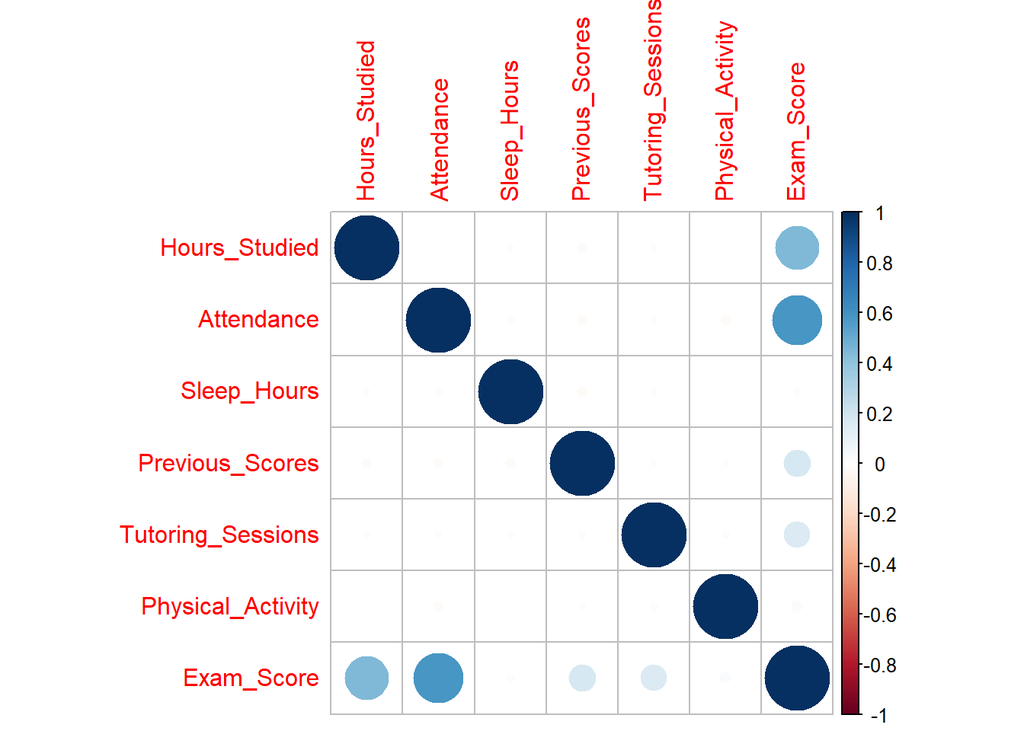

```r
corrplot::corrplot(Correlations)
```

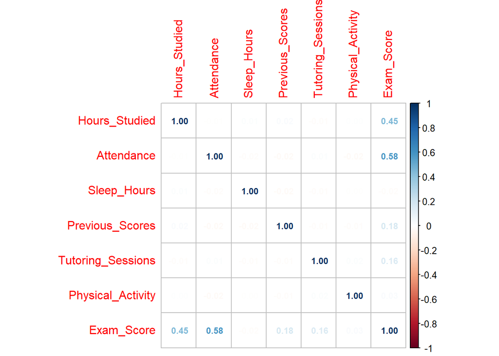

```r
corrplot::corrplot(Correlations, method = "number", number.cex = 0.75)
```

## PCA

```r
pca <- princomp(db, cor = TRUE)
names(pca)
```

```
## [1] "sdev"     "loadings" "center"   "scale"    "n.obs"    "scores"   "call"
```

```r
summary(pca)
```

```
## Importance of components:
##                           Comp.1    Comp.2    Comp.3    Comp.4    Comp.5
## Standard deviation     1.3285495 1.0246076 1.0108303 1.0083346 0.9852260
## Proportion of Variance 0.2521491 0.1499744 0.1459683 0.1452484 0.1386672
## Cumulative Proportion  0.2521491 0.4021235 0.5480918 0.6933402 0.8320074
##                           Comp.6     Comp.7
## Standard deviation     0.9749880 0.47470714
## Proportion of Variance 0.1358002 0.03219241
## Cumulative Proportion  0.9678076 1.00000000
```

```r
pca$loadings[,1:7]
```

```
##                        Comp.1       Comp.2      Comp.3       Comp.4
## Hours_Studied      0.40814259  0.541571903  0.28165125  0.084050661
## Attendance         0.53198612 -0.445007846 -0.24114852  0.205839335
## Sleep_Hours       -0.02785611  0.142394737  0.39046229  0.704610496
## Previous_Scores    0.15959029  0.527547939 -0.27814901 -0.442750037
## Tutoring_Sessions  0.14544485 -0.457309962  0.32022080 -0.368627088
## Physical_Activity  0.01368981 -0.030673620  0.72791595 -0.349469417
## Exam_Score         0.70910067  0.003395515  0.01700878  0.006877829
##                         Comp.5      Comp.6       Comp.7
## Hours_Studied      0.022591207  0.53450427  0.409294984
## Attendance         0.227304213 -0.28102743  0.536463167
## Sleep_Hours       -0.391506062 -0.42038347 -0.003429163
## Previous_Scores   -0.302204023 -0.55221648  0.162970320
## Tutoring_Sessions -0.696284403  0.16232481  0.141861871
## Physical_Activity  0.467330514 -0.35647598  0.037527079
## Exam_Score         0.002895476 -0.01545951 -0.704684844
```

## Análisis del PCA

```r
library(FactoMineR)
library(factoextra)
```

```r
library(corrplot)
(dec.pca <- PCA(db, scale.unit = TRUE, ncp = Inf, graph = F))
```

```
## **Results for the Principal Component Analysis (PCA)**
## The analysis was performed on 6607 individuals, described by 7 variables
## *The results are available in the following objects:
##
##    name               description
## 1  "$eig"             "eigenvalues"
## 2  "$var"             "results for the variables"
## 3  "$var$coord"       "coord. for the variables"
## 4  "$var$cor"         "correlations variables - dimensions"
## 5  "$var$cos2"        "cos2 for the variables"
## 6  "$var$contrib"     "contributions of the variables"
## 7  "$ind"             "results for the individuals"
## 8  "$ind$coord"       "coord. for the individuals"
## 9  "$ind$cos2"        "cos2 for the individuals"
## 10 "$ind$contrib"     "contributions of the individuals"
## 11 "$call"            "summary statistics"
## 12 "$call$centre"     "mean of the variables"
## 13 "$call$ecart.type" "standard error of the variables"
## 14 "$call$row.w"      "weights for the individuals"
## 15 "$call$col.w"      "weights for the variables"
```

```r
summary(dec.pca)
```

```
##
## Call:
## PCA(X = db, scale.unit = TRUE, ncp = Inf, graph = F)
##
##
## Eigenvalues
##                        Dim.1   Dim.2   Dim.3   Dim.4   Dim.5   Dim.6   Dim.7
## Variance               1.765   1.050   1.022   1.017   0.971   0.951   0.225
## % of var.             25.215  14.997  14.597  14.525  13.867  13.580   3.219
## Cumulative % of var.  25.215  40.212  54.809  69.334  83.201  96.781 100.000
##
## Individuals (the 10 first)
##                       Dist    Dim.1    ctr   cos2    Dim.2    ctr   cos2
## 1                 |  1.370 |  0.150  0.000  0.012 |  0.594  0.005  0.188 |
## 2                 |  2.714 | -2.062  0.036  0.577 | -0.191  0.001  0.005 |
## 3                 |  2.882 |  2.588  0.057  0.806 |  0.037  0.000  0.000 |
## 4                 |  2.820 |  1.908  0.031  0.458 |  1.559  0.035  0.305 |
## 5                 |  2.258 |  1.091  0.010  0.234 | -1.608  0.037  0.508 |
## 6                 |  2.078 |  1.304  0.015  0.394 | -0.350  0.002  0.028 |
## 7                 |  1.918 |  0.608  0.003  0.101 |  0.611  0.005  0.102 |
## 8                 |  2.323 | -0.304  0.001  0.017 | -0.277  0.001  0.014 |
## 9                 |  2.766 |  0.636  0.003  0.053 | -0.113  0.000  0.002 |
## 10                |  3.173 |  1.692  0.025  0.284 |  0.023  0.000  0.000 |
##                    Dim.3    ctr   cos2
## 1                 -0.276  0.001  0.041 |
## 2                  1.690  0.042  0.388 |
## 3                  0.388  0.002  0.018 |
## 4                  0.668  0.007  0.056 |
## 5                  0.757  0.008  0.112 |
## 6                  0.207  0.001  0.010 |
## 7                 -0.343  0.002  0.032 |
## 8                 -0.329  0.002  0.020 |
## 9                 -2.572  0.098  0.864 |
## 10                 1.170  0.020  0.136 |
##
## Variables
##                      Dim.1    ctr   cos2    Dim.2    ctr   cos2    Dim.3    ctr
## Hours_Studied     |  0.542 16.658  0.294 |  0.555 29.330  0.308 |  0.285  7.933
## Attendance        |  0.707 28.301  0.500 | -0.456 19.803  0.208 | -0.244  5.815
## Sleep_Hours       | -0.037  0.078  0.001 |  0.146  2.028  0.021 |  0.395 15.246
## Previous_Scores   |  0.212  2.547  0.045 |  0.541 27.831  0.292 | -0.281  7.737
## Tutoring_Sessions |  0.193  2.115  0.037 | -0.469 20.913  0.220 |  0.324 10.254
## Physical_Activity |  0.018  0.019  0.000 | -0.031  0.094  0.001 |  0.736 52.986
## Exam_Score        |  0.942 50.282  0.888 |  0.003  0.001  0.000 |  0.017  0.029
##                     cos2
## Hours_Studied      0.081 |
## Attendance         0.059 |
## Sleep_Hours        0.156 |
## Previous_Scores    0.079 |
## Tutoring_Sessions  0.105 |
## Physical_Activity  0.541 |
## Exam_Score         0.000 |
```

```r
get_pca(dec.pca)
```

```
## Principal Component Analysis Results for variables
##  ===================================================
##   Name       Description
## 1 "$coord"   "Coordinates for the variables"
## 2 "$cor"     "Correlations between variables and dimensions"
## 3 "$cos2"    "Cos2 for the variables"
## 4 "$contrib" "contributions of the variables"
```

```r
get_eigenvalue(dec.pca)
```

```
##       eigenvalue variance.percent cumulative.variance.percent
## Dim.1  1.7650438        25.214912                    25.21491
## Dim.2  1.0498208        14.997440                    40.21235
## Dim.3  1.0217778        14.596826                    54.80918
## Dim.4  1.0167387        14.524839                    69.33402
## Dim.5  0.9706703        13.866719                    83.20074
## Dim.6  0.9506016        13.580023                    96.78076
## Dim.7  0.2253469         3.219241                   100.00000
```

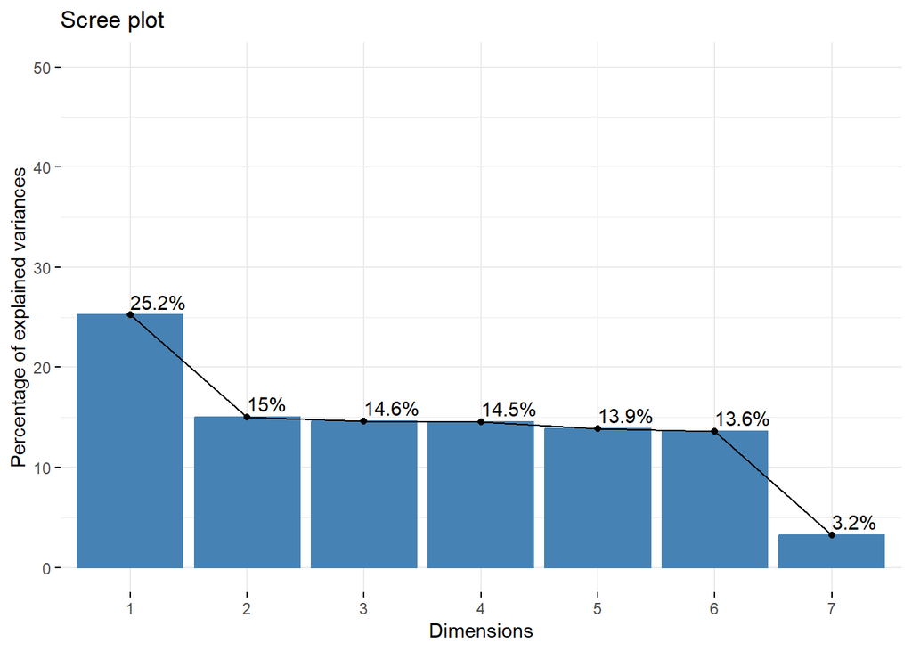

```r
fviz_eig(dec.pca, addlabels = TRUE, ylim = c(0, 50))
```

Según los eigenvalue sólo nos quedaríamos con las primeras 4 dimensiones.  
Según el método del codo deberíamos quedarnos con las primeras 6 dimensiones.  
Según el porcentaje de varianza nos deberíamos quedar con las primeras 5 dimensiones.  
Ninguno de los métodos nos limita a dos o tres dimensiones por tanto debemos ver gráficamente qué ocurre y encontrar nosotros manualmente las variables latentes.

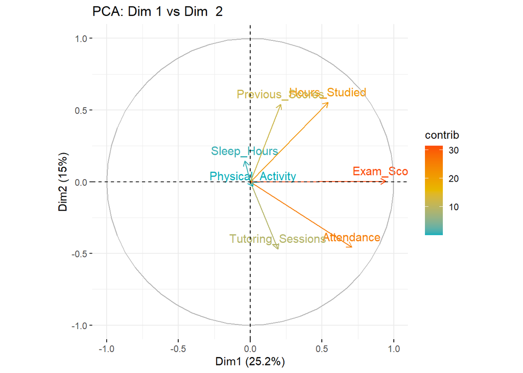

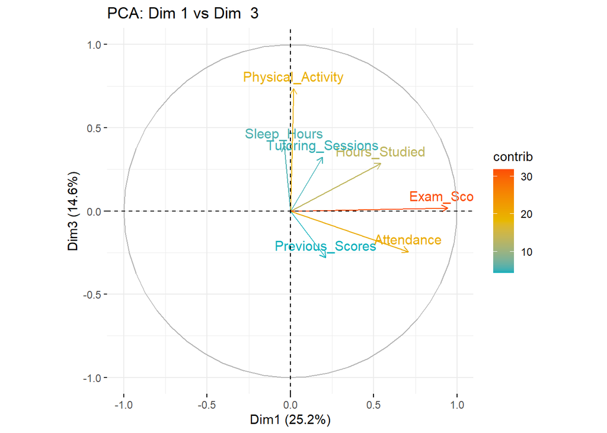

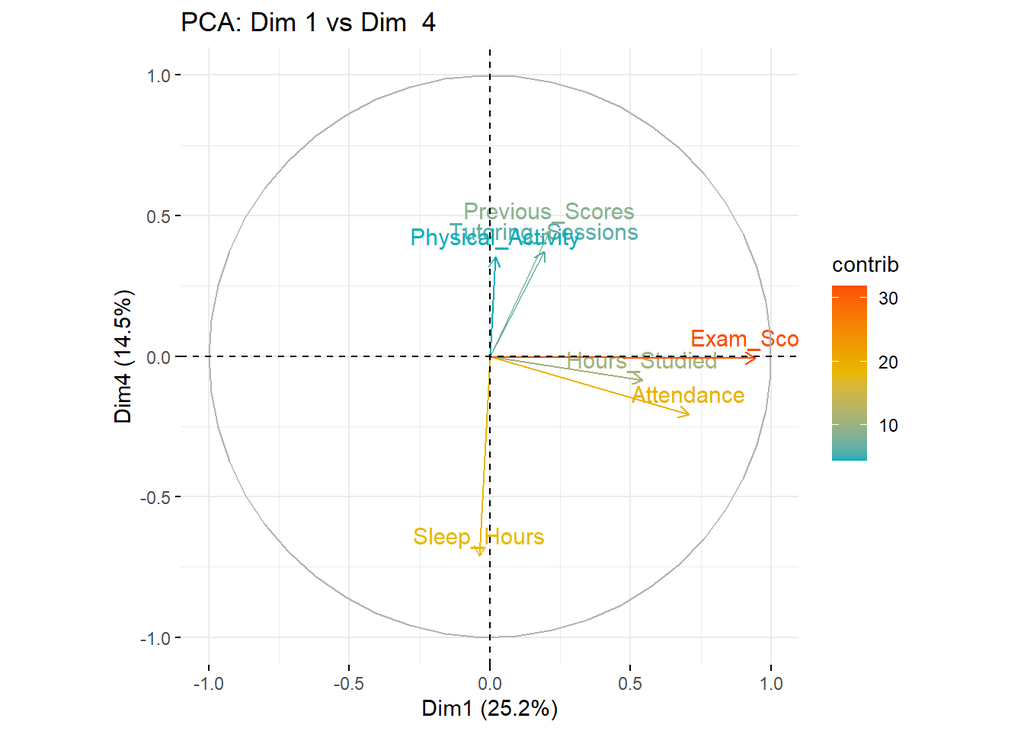

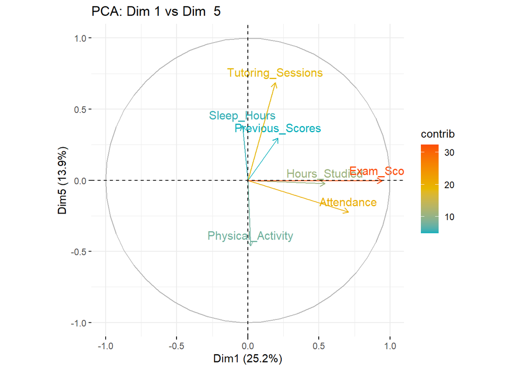

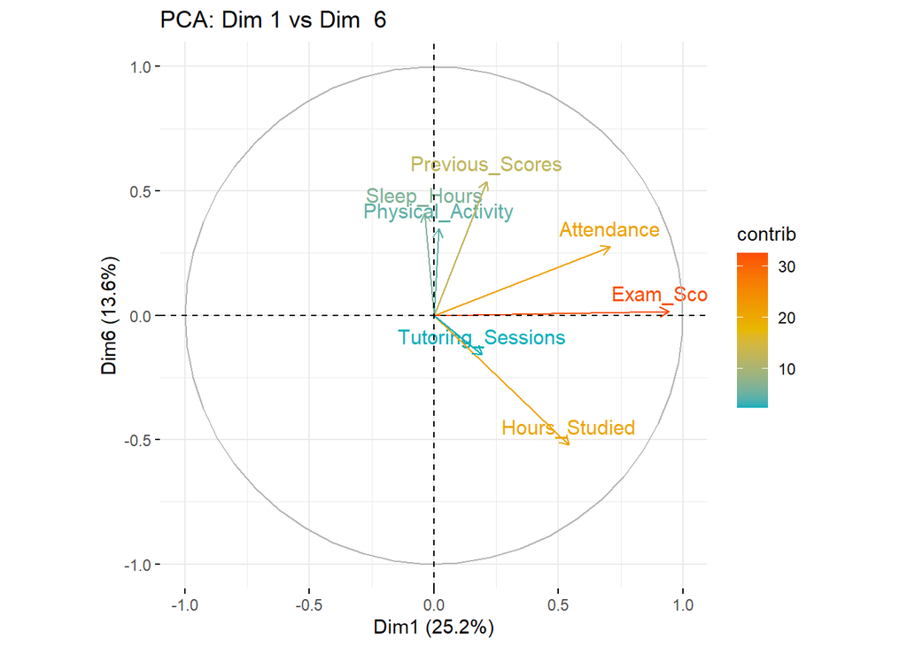

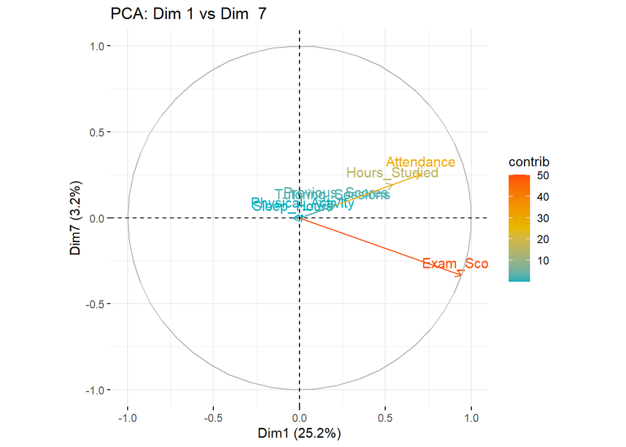

```r
for (i in 2:7) {
  print(fviz_pca_var(dec.pca, axes = c(1, i), col.var = "contrib",
                     gradient.cols = c("#00AFBB", "#E7B800", "#FC4E07"),
                     title = paste("PCA: Dim 1 vs Dim ", i)))
}
```

**Gráfico 1: Dim 1 vs Dim 2**

**Gráfico 2: Dim 1 vs Dim 3**

- `Exam_Score` mantiene su peso dominante en Dim 1.
- `Physical_Activity` se vuelve altamente relevante para Dim 3, siendo la variable más alejada en esa dirección.
- `Sleep_Hours`, `Tutoring_Sessions` y `Previous_Scores` también tienen presencia importante en Dim 3.
- Esto sugiere que Dim 3 podría estar captando un componente relacionado con el autocuidado y el apoyo académico complementario.

**Gráfico 3: Dim 1 vs Dim 4**

- `Exam_Score` continúa siendo la principal variable en Dim 1.
- `Sleep_Hours` se proyecta negativamente en Dim 4, destacando como una dimensión opuesta a la exigencia académica.
- `Hours_Studied` y `Attendance` siguen estando presentes con contribuciones cruzadas entre ambas dimensiones.
- Dim 4 parece recoger aspectos de equilibrio personal frente al esfuerzo académico.

**Gráfico 4: Dim 1 vs Dim 5**

- `Tutoring_Sessions` sobresale en Dim 5, mientras que `Physical_Activity` apunta en sentido opuesto, posiblemente en conflicto con el apoyo académico.
- `Exam_Score` se mantiene como principal contribuidor a Dim 1.
- Esta dimensión puede representar la estrategia del estudiante: dependencia del apoyo externo versus hábitos individuales como la actividad física.

**Gráfico 5: Dim 1 vs Dim 6**

- `Exam_Score`, `Attendance` y `Hours_Studied` mantienen su peso en Dim 1.
- Dim 6 agrupa a `Sleep_Hours`, `Physical_Activity` y `Previous_Scores`, lo que podría reflejar una dimensión de regularidad, rutina o equilibrio personal.
- `Tutoring_Sessions` tiene un posicionamiento único en Dim 6, lo que añade complejidad a la interpretación.

**Gráfico 6: Dim 1 vs Dim 7**

```r
(var <- get_pca_var(dec.pca))
```

```
## Principal Component Analysis Results for variables
##  ===================================================
##   Name       Description
## 1 "$coord"   "Coordinates for the variables"
## 2 "$cor"     "Correlations between variables and dimensions"
## 3 "$cos2"    "Cos2 for the variables"
## 4 "$contrib" "contributions of the variables"
```

```r
(Correl <- cor(db, pca$scores))
```

```
##                        Comp.1       Comp.2      Comp.3       Comp.4
## Hours_Studied      0.54223765  0.554898714  0.28470161  0.084751192
## Attendance         0.70676989 -0.455958442 -0.24376023  0.207554931
## Sleep_Hours       -0.03700822  0.145898737  0.39469111  0.710483167
## Previous_Scores    0.21202360  0.540529653 -0.28116144 -0.446440197
## Tutoring_Sessions  0.19323068 -0.468563285  0.32368888 -0.371699460
## Physical_Activity  0.01818759 -0.031428426  0.73579948 -0.352382117
## Exam_Score         0.94207535  0.003479071  0.01719299  0.006935153
##                         Comp.5      Comp.6       Comp.7
## Hours_Studied      0.022257445  0.52113525  0.194295251
## Attendance         0.223946025 -0.27399837  0.254662896
## Sleep_Hours       -0.385721960 -0.40986884 -0.001627848
## Previous_Scores   -0.297739268 -0.53840445  0.077363174
## Tutoring_Sessions -0.685997512  0.15826475  0.067342843
## Physical_Activity  0.460426183 -0.34755980  0.017814372
## Exam_Score         0.002852699 -0.01507284 -0.334518927
```

```r
var$coord
```

```
##                         Dim.1        Dim.2       Dim.3        Dim.4
## Hours_Studied      0.54223765  0.554898714  0.28470161 -0.084751192
## Attendance         0.70676989 -0.455958442 -0.24376023 -0.207554931
## Sleep_Hours       -0.03700822  0.145898737  0.39469111 -0.710483167
## Previous_Scores    0.21202360  0.540529653 -0.28116144  0.446440197
## Tutoring_Sessions  0.19323068 -0.468563285  0.32368888  0.371699460
## Physical_Activity  0.01818759 -0.031428426  0.73579948  0.352382117
## Exam_Score         0.94207535  0.003479071  0.01719299 -0.006935153
##                          Dim.5       Dim.6        Dim.7
## Hours_Studied     -0.022257445 -0.52113525  0.194295251
## Attendance        -0.223946025  0.27399837  0.254662896
## Sleep_Hours        0.385721960  0.40986884 -0.001627848
## Previous_Scores    0.297739268  0.53840445  0.077363174
## Tutoring_Sessions  0.685997512 -0.15826475  0.067342843
## Physical_Activity -0.460426183  0.34755980  0.017814372
## Exam_Score        -0.002852699  0.01507284 -0.334518927
```

```r
(Quality <- Correl^2)
```

```
##                         Comp.1       Comp.2      Comp.3       Comp.4
## Hours_Studied     0.2940216641 3.079126e-01 0.081055006 7.182765e-03
## Attendance        0.4995236837 2.078981e-01 0.059419048 4.307905e-02
## Sleep_Hours       0.0013696086 2.128644e-02 0.155781070 5.047863e-01
## Previous_Scores   0.0449540077 2.921723e-01 0.079051757 1.993088e-01
## Tutoring_Sessions 0.0373380959 2.195516e-01 0.104774488 1.381605e-01
## Physical_Activity 0.0003307885 9.877459e-04 0.541400871 1.241732e-01
## Exam_Score        0.8875059598 1.210394e-05 0.000295599 4.809634e-05
##                         Comp.5       Comp.6       Comp.7
## Hours_Studied     4.953939e-04 0.2715819436 3.775064e-02
## Attendance        5.015182e-02 0.0750751055 6.485319e-02
## Sleep_Hours       1.487814e-01 0.1679924693 2.649889e-06
## Previous_Scores   8.864867e-02 0.2898793481 5.985061e-03
## Tutoring_Sessions 4.705926e-01 0.0250477297 4.535059e-03
## Physical_Activity 2.119923e-01 0.1207978162 3.173519e-04
## Exam_Score        8.137889e-06 0.0002271904 1.119029e-01
```

```r
var$cos2
```

```
##                          Dim.1        Dim.2       Dim.3        Dim.4
## Hours_Studied     0.2940216641 3.079126e-01 0.081055006 7.182765e-03
## Attendance        0.4995236837 2.078981e-01 0.059419048 4.307905e-02
## Sleep_Hours       0.0013696086 2.128644e-02 0.155781070 5.047863e-01
## Previous_Scores   0.0449540077 2.921723e-01 0.079051757 1.993088e-01
## Tutoring_Sessions 0.0373380959 2.195516e-01 0.104774488 1.381605e-01
## Physical_Activity 0.0003307885 9.877459e-04 0.541400871 1.241732e-01
## Exam_Score        0.8875059598 1.210394e-05 0.000295599 4.809634e-05
##                          Dim.5        Dim.6        Dim.7
## Hours_Studied     4.953939e-04 0.2715819436 3.775064e-02
## Attendance        5.015182e-02 0.0750751055 6.485319e-02
## Sleep_Hours       1.487814e-01 0.1679924693 2.649889e-06
## Previous_Scores   8.864867e-02 0.2898793481 5.985061e-03
## Tutoring_Sessions 4.705926e-01 0.0250477297 4.535059e-03
## Physical_Activity 2.119923e-01 0.1207978162 3.173519e-04
## Exam_Score        8.137889e-06 0.0002271904 1.119029e-01
```

## Análisis gráfico

```r
head(var$coord)
```

```
##                         Dim.1       Dim.2      Dim.3       Dim.4       Dim.5
## Hours_Studied      0.54223765  0.55489871  0.2847016 -0.08475119 -0.02225745
## Attendance         0.70676989 -0.45595844 -0.2437602 -0.20755493 -0.22394603
## Sleep_Hours       -0.03700822  0.14589874  0.3946911 -0.71048317  0.38572196
## Previous_Scores    0.21202360  0.54052965 -0.2811614  0.44644020  0.29773927
## Tutoring_Sessions  0.19323068 -0.46856329  0.3236889  0.37169946  0.68599751
## Physical_Activity  0.01818759 -0.03142843  0.7357995  0.35238212 -0.46042618
##                        Dim.6        Dim.7
## Hours_Studied     -0.5211352  0.194295251
## Attendance         0.2739984  0.254662896
## Sleep_Hours        0.4098688 -0.001627848
## Previous_Scores    0.5384044  0.077363174
## Tutoring_Sessions -0.1582647  0.067342843
## Physical_Activity  0.3475598  0.017814372
```

```r
head(var$cos2)
```

```
##                          Dim.1        Dim.2      Dim.3       Dim.4        Dim.5
## Hours_Studied     0.2940216641 0.3079125828 0.08105501 0.007182765 0.0004953939
## Attendance        0.4995236837 0.2078981011 0.05941905 0.043079049 0.0501518222
## Sleep_Hours       0.0013696086 0.0212864414 0.15578107 0.504786331 0.1487814304
## Previous_Scores   0.0449540077 0.2921723053 0.07905176 0.199308849 0.0886486714
## Tutoring_Sessions 0.0373380959 0.2195515521 0.10477449 0.138160489 0.4705925871
## Physical_Activity 0.0003307885 0.0009877459 0.54140087 0.124173156 0.2119922704
##                        Dim.6        Dim.7
## Hours_Studied     0.27158194 3.775064e-02
## Attendance        0.07507511 6.485319e-02
## Sleep_Hours       0.16799247 2.649889e-06
## Previous_Scores   0.28987935 5.985061e-03
## Tutoring_Sessions 0.02504773 4.535059e-03
## Physical_Activity 0.12079782 3.173519e-04
```

```r
head(var$contrib)
```

```
##                         Dim.1      Dim.2     Dim.3      Dim.4       Dim.5
## Hours_Studied     16.65803776 29.3300126  7.932743  0.7064514  0.05103626
## Attendance        28.30092269 19.8031983  5.815261  4.2369832  5.16672051
## Sleep_Hours        0.07759630  2.0276261 15.246080 49.6475951 15.32769967
## Previous_Scores    2.54690606 27.8306827  7.736687 19.6027595  9.13272717
## Tutoring_Sessions  2.11542035 20.9132402 10.254136 13.5885930 48.48119703
## Physical_Activity  0.01874109  0.0940871 52.986163 12.2128874 21.83978098
##                       Dim.6        Dim.7
## Hours_Studied     28.569481 16.752238414
## Attendance         7.897641 28.779272996
## Sleep_Hours       17.672227  0.001175916
## Previous_Scores   30.494305  2.655932509
## Tutoring_Sessions  2.634935  2.012479049
## Physical_Activity 12.707512  0.140828165
```

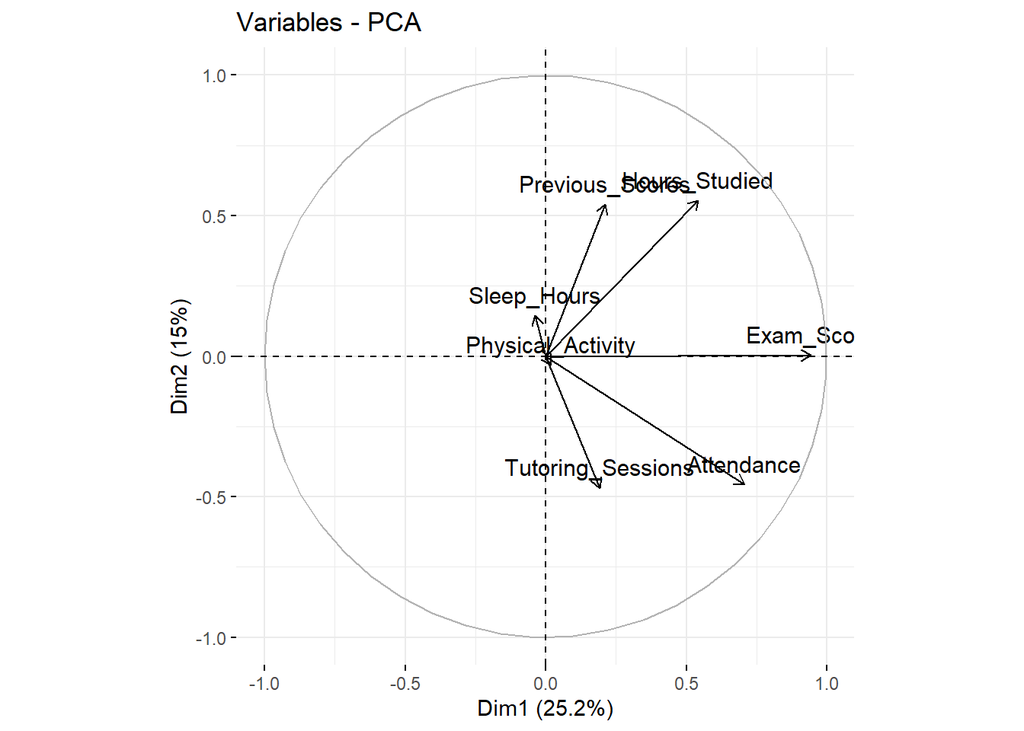

```r
fviz_pca_var(dec.pca, col.var = "black")
```

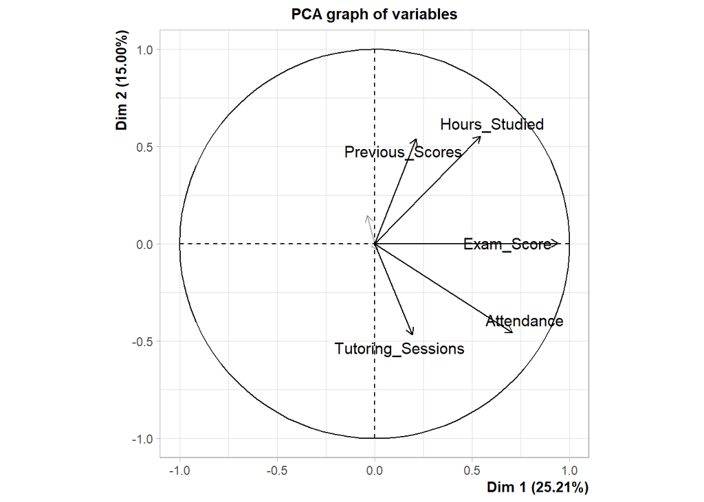

```r
plot(dec.pca, choix="var", select="contrib 5")
```

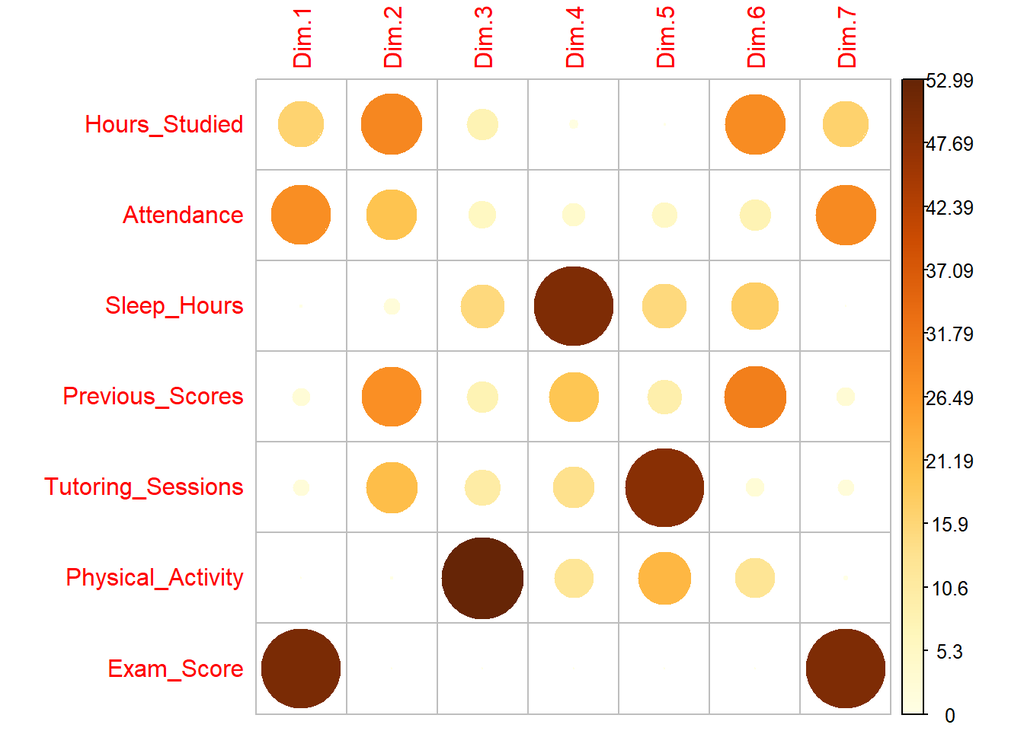

```r
corrplot(var$contrib, is.corr=FALSE)
```

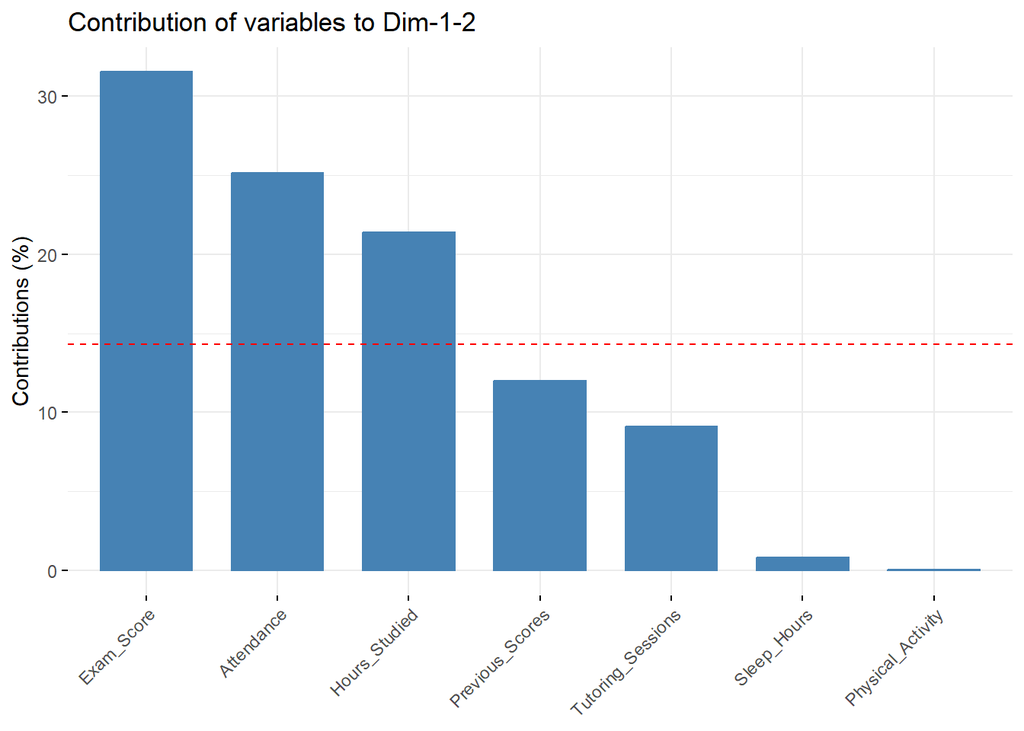

```r
fviz_contrib(dec.pca, choice = "var", axes = 1:2)
```

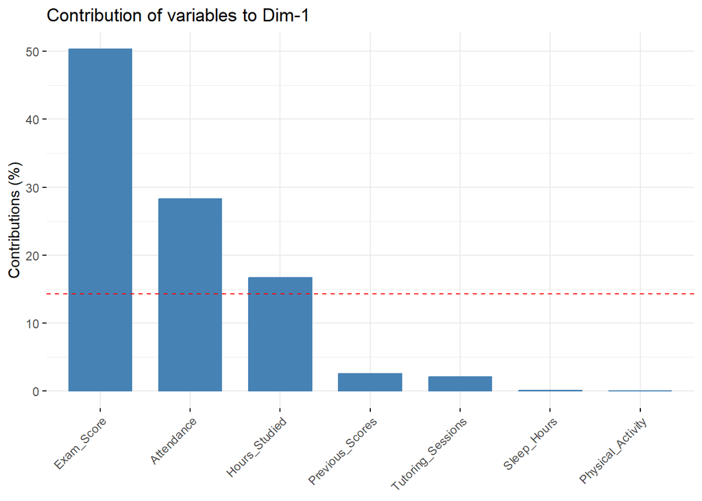

```r
fviz_contrib(dec.pca, choice = "var", axes = 1)
```

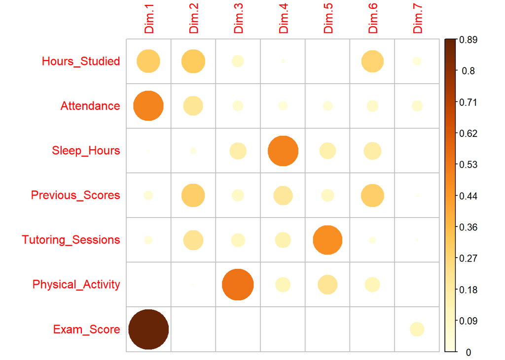

```r
corrplot(var$cos2, is.corr = FALSE)
```

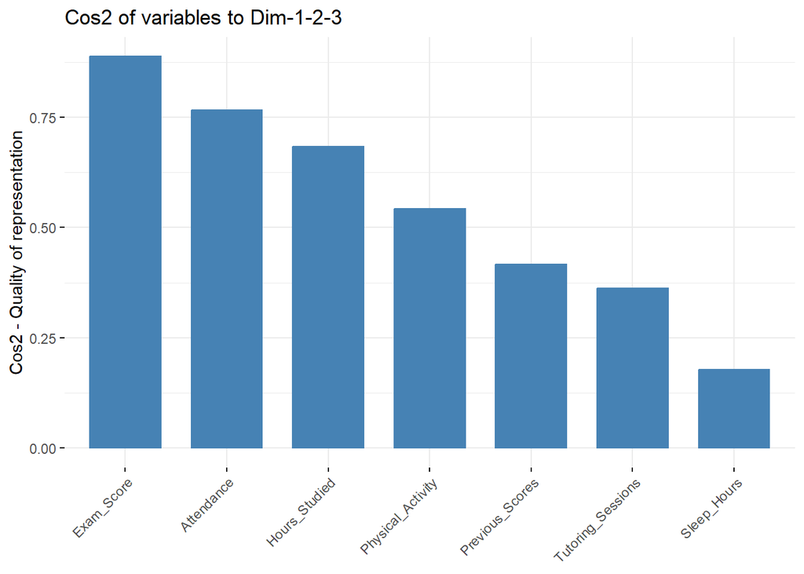

```r
fviz_cos2(dec.pca, choice = "var", axes = 1:3)
```

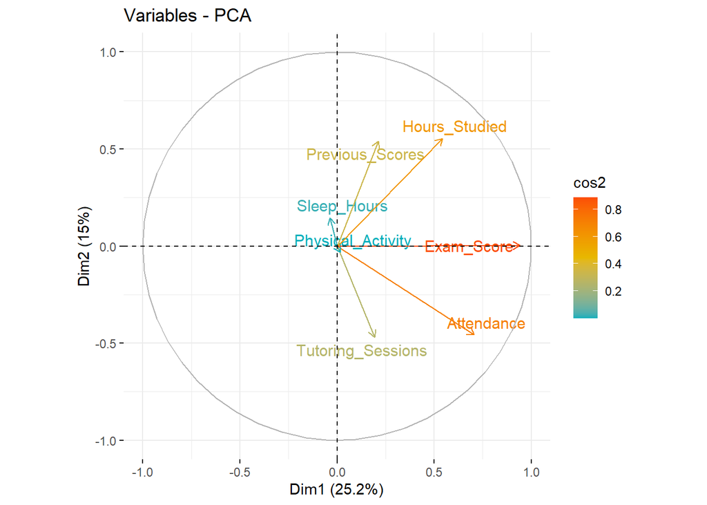

```r
fviz_pca_var(dec.pca, col.var = "cos2", gradient.cols = c("#00AFBB", "#E7B800", "#FC4E07"),
             repel = TRUE) # Avoid text overlapping
```

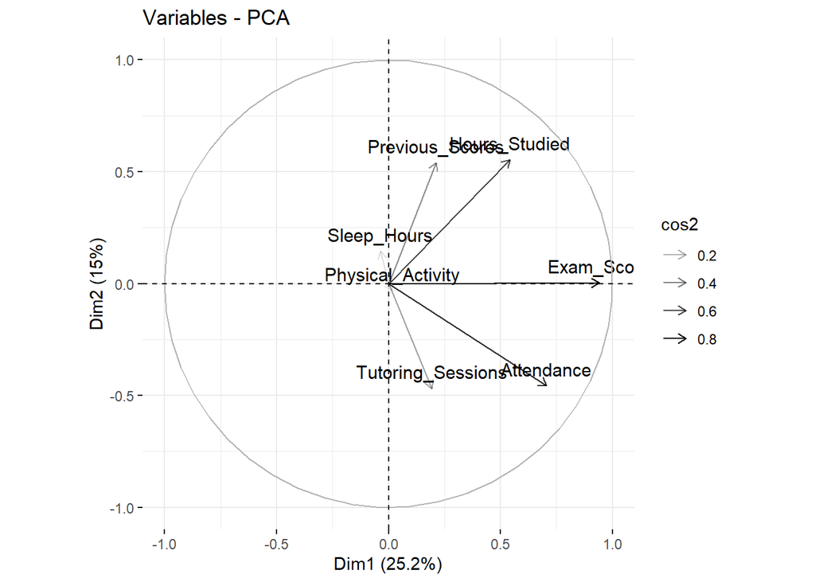

```r
fviz_pca_var(dec.pca, alpha.var = "cos2")
```

```r
head(var$contrib, 4)
```

```
##                      Dim.1     Dim.2     Dim.3      Dim.4       Dim.5     Dim.6
## Hours_Studied   16.6580378 29.330013  7.932743  0.7064514  0.05103626 28.569481
## Attendance      28.3009227 19.803198  5.815261  4.2369832  5.16672051  7.897641
## Sleep_Hours      0.0775963  2.027626 15.246080 49.6475951 15.32769967 17.672227
## Previous_Scores  2.5469061 27.830683  7.736687 19.6027595  9.13272717 30.494305
##                        Dim.7
## Hours_Studied   16.752238414
## Attendance      28.779272996
## Sleep_Hours      0.001175916
## Previous_Scores  2.655932509
```

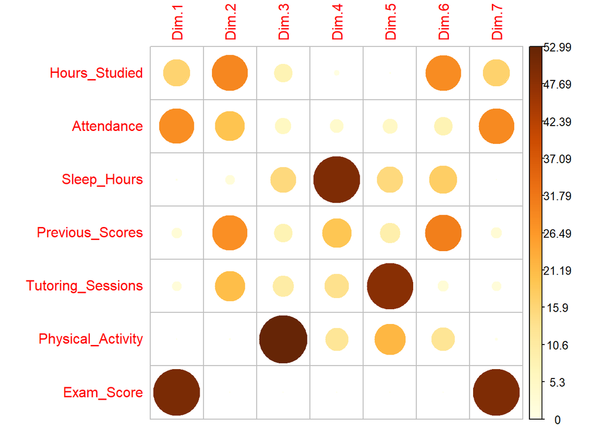

```r
corrplot(var$contrib, is.corr = FALSE)
```

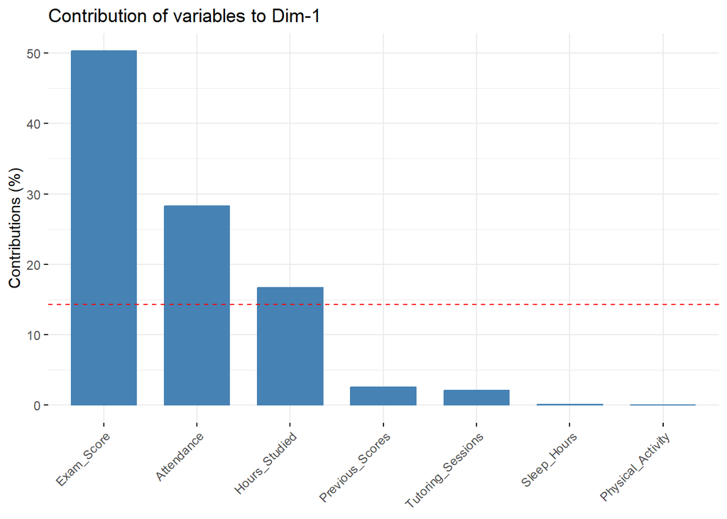

```r
fviz_contrib(dec.pca, choice = "var", axes = 1, top = 10)
```

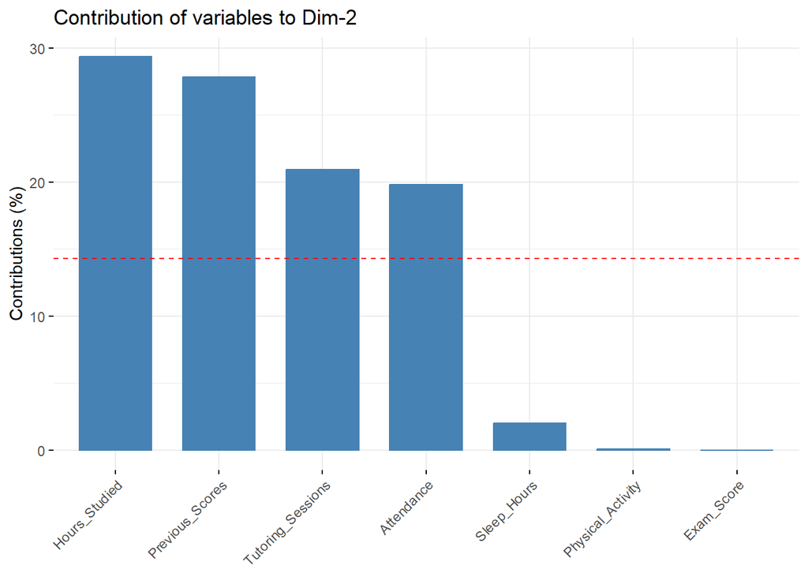

```r
fviz_contrib(dec.pca, choice = "var", axes = 2, top = 10)
```

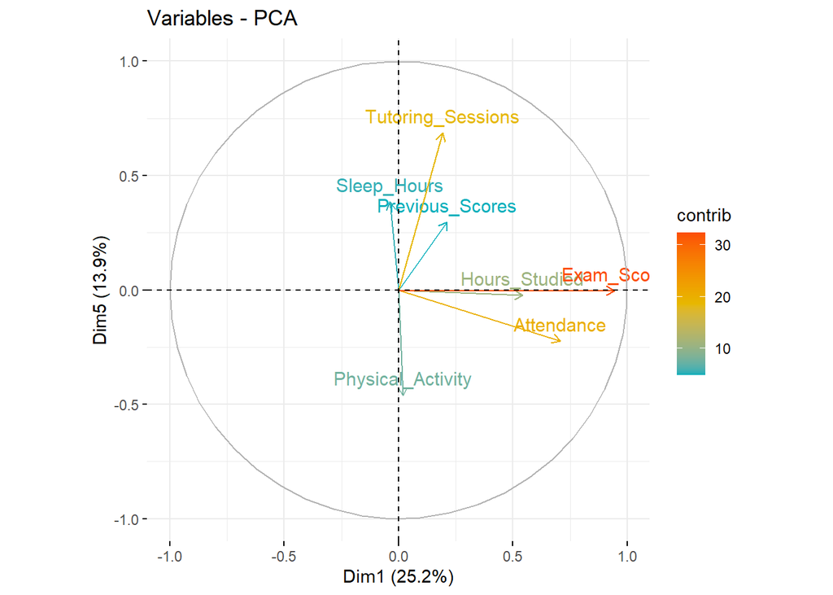

```r
fviz_pca_var(dec.pca, axes=c(1,5), col.var = "contrib", gradient.cols = c("#00AFBB", "#E7B800", "#FC4E07"))
```